# Risk Factor Analysis

## Outcome Variable

**Outcome Variable:** ever_wasted

## Predictor Variables

**Intervention Variable:** perdiar24

**Adjustment Set:**

- arm
- sex
- W_mage
- meducyrs
- feducyrs
- hhwealth_quart
- hfoodsec
- hdlvry
- W_birthwt
- W_birthlen
- single
- W_nrooms
- month
- brthmon
- impfloor
- impsan
- safeh20
- delta_W_mage
- delta_meducyrs
- delta_feducyrs
- delta_hhwealth_quart
- delta_hfoodsec
- delta_hdlvry
- delta_W_birthwt
- delta_W_birthlen
- delta_single
- delta_W_nrooms
- delta_month
- delta_brthmon
- delta_impfloor
- delta_impsan
- delta_safeh20

## Stratifying Variables

The analysis was stratified on these variable(s):

- agecat
- studyid
- country

## Data Summary

| agecat | studyid | country | perdiar24 | ever_wasted | n_cell | n |
| --- | --- | --- | --- | --- | --- | --- |
| 0-24 months (no birth wast) | ki0047075b-MAL-ED | BANGLADESH | 0% | 0 | 17 | 263 |
| 0-24 months (no birth wast) | ki0047075b-MAL-ED | BANGLADESH | 0% | 1 | 3 | 263 |
| 0-24 months (no birth wast) | ki0047075b-MAL-ED | BANGLADESH | (0%, 5%] | 0 | 112 | 263 |
| 0-24 months (no birth wast) | ki0047075b-MAL-ED | BANGLADESH | (0%, 5%] | 1 | 36 | 263 |
| 0-24 months (no birth wast) | ki0047075b-MAL-ED | BANGLADESH | >5% | 0 | 76 | 263 |
| 0-24 months (no birth wast) | ki0047075b-MAL-ED | BANGLADESH | >5% | 1 | 19 | 263 |
| 0-24 months (no birth wast) | ki0047075b-MAL-ED | BRAZIL | 0% | 0 | 124 | 233 |
| 0-24 months (no birth wast) | ki0047075b-MAL-ED | BRAZIL | 0% | 1 | 6 | 233 |
| 0-24 months (no birth wast) | ki0047075b-MAL-ED | BRAZIL | (0%, 5%] | 0 | 95 | 233 |
| 0-24 months (no birth wast) | ki0047075b-MAL-ED | BRAZIL | (0%, 5%] | 1 | 6 | 233 |
| 0-24 months (no birth wast) | ki0047075b-MAL-ED | BRAZIL | >5% | 0 | 1 | 233 |
| 0-24 months (no birth wast) | ki0047075b-MAL-ED | BRAZIL | >5% | 1 | 1 | 233 |
| 0-24 months (no birth wast) | ki0047075b-MAL-ED | INDIA | 0% | 0 | 11 | 246 |
| 0-24 months (no birth wast) | ki0047075b-MAL-ED | INDIA | 0% | 1 | 2 | 246 |
| 0-24 months (no birth wast) | ki0047075b-MAL-ED | INDIA | (0%, 5%] | 0 | 117 | 246 |
| 0-24 months (no birth wast) | ki0047075b-MAL-ED | INDIA | (0%, 5%] | 1 | 74 | 246 |
| 0-24 months (no birth wast) | ki0047075b-MAL-ED | INDIA | >5% | 0 | 27 | 246 |
| 0-24 months (no birth wast) | ki0047075b-MAL-ED | INDIA | >5% | 1 | 15 | 246 |
| 0-24 months (no birth wast) | ki0047075b-MAL-ED | NEPAL | 0% | 0 | 16 | 239 |
| 0-24 months (no birth wast) | ki0047075b-MAL-ED | NEPAL | 0% | 1 | 1 | 239 |
| 0-24 months (no birth wast) | ki0047075b-MAL-ED | NEPAL | (0%, 5%] | 0 | 112 | 239 |
| 0-24 months (no birth wast) | ki0047075b-MAL-ED | NEPAL | (0%, 5%] | 1 | 31 | 239 |
| 0-24 months (no birth wast) | ki0047075b-MAL-ED | NEPAL | >5% | 0 | 65 | 239 |
| 0-24 months (no birth wast) | ki0047075b-MAL-ED | NEPAL | >5% | 1 | 14 | 239 |
| 0-24 months (no birth wast) | ki0047075b-MAL-ED | PERU | 0% | 0 | 28 | 302 |
| 0-24 months (no birth wast) | ki0047075b-MAL-ED | PERU | 0% | 1 | 0 | 302 |
| 0-24 months (no birth wast) | ki0047075b-MAL-ED | PERU | (0%, 5%] | 0 | 106 | 302 |
| 0-24 months (no birth wast) | ki0047075b-MAL-ED | PERU | (0%, 5%] | 1 | 7 | 302 |
| 0-24 months (no birth wast) | ki0047075b-MAL-ED | PERU | >5% | 0 | 147 | 302 |
| 0-24 months (no birth wast) | ki0047075b-MAL-ED | PERU | >5% | 1 | 14 | 302 |

[output cut: 270 more lines]

The following strata were considered:

- agecat: 0-24 months (no birth wast), studyid: ki0047075b-MAL-ED, country: BANGLADESH
- agecat: 0-24 months (no birth wast), studyid: ki0047075b-MAL-ED, country: BRAZIL
- agecat: 0-24 months (no birth wast), studyid: ki0047075b-MAL-ED, country: INDIA
- agecat: 0-24 months (no birth wast), studyid: ki0047075b-MAL-ED, country: NEPAL
- agecat: 0-24 months (no birth wast), studyid: ki0047075b-MAL-ED, country: PERU
- agecat: 0-24 months (no birth wast), studyid: ki0047075b-MAL-ED, country: SOUTH AFRICA
- agecat: 0-24 months (no birth wast), studyid: ki0047075b-MAL-ED, country: TANZANIA, UNITED REPUBLIC OF
- agecat: 0-24 months (no birth wast), studyid: ki1000109-EE, country: PAKISTAN
- agecat: 0-24 months (no birth wast), studyid: ki1000304b-SAS-FoodSuppl, country: INDIA
- agecat: 0-24 months (no birth wast), studyid: ki1017093-NIH-Birth, country: BANGLADESH
- agecat: 0-24 months (no birth wast), studyid: ki1017093b-PROVIDE, country: BANGLADESH
- agecat: 0-24 months (no birth wast), studyid: ki1017093c-NIH-Crypto, country: BANGLADESH
- agecat: 0-24 months (no birth wast), studyid: ki1112895-Guatemala BSC, country: GUATEMALA
- agecat: 0-24 months (no birth wast), studyid: ki1112895-iLiNS-Zinc, country: BURKINA FASO
- agecat: 0-24 months (no birth wast), studyid: ki1114097-CMIN, country: BANGLADESH
- agecat: 0-24 months (no birth wast), studyid: ki1114097-CONTENT, country: PERU
- agecat: 0-24 months (no birth wast), studyid: kiGH5241-JiVitA-4, country: BANGLADESH
- agecat: 0-6 months (no birth wast), studyid: ki0047075b-MAL-ED, country: BANGLADESH
- agecat: 0-6 months (no birth wast), studyid: ki0047075b-MAL-ED, country: BRAZIL
- agecat: 0-6 months (no birth wast), studyid: ki0047075b-MAL-ED, country: INDIA
- agecat: 0-6 months (no birth wast), studyid: ki0047075b-MAL-ED, country: NEPAL
- agecat: 0-6 months (no birth wast), studyid: ki0047075b-MAL-ED, country: PERU
- agecat: 0-6 months (no birth wast), studyid: ki0047075b-MAL-ED, country: SOUTH AFRICA
- agecat: 0-6 months (no birth wast), studyid: ki0047075b-MAL-ED, country: TANZANIA, UNITED REPUBLIC OF
- agecat: 0-6 months (no birth wast), studyid: ki1000109-EE, country: PAKISTAN
- agecat: 0-6 months (no birth wast), studyid: ki1000304b-SAS-FoodSuppl, country: INDIA
- agecat: 0-6 months (no birth wast), studyid: ki1017093-NIH-Birth, country: BANGLADESH
- agecat: 0-6 months (no birth wast), studyid: ki1017093b-PROVIDE, country: BANGLADESH
- agecat: 0-6 months (no birth wast), studyid: ki1017093c-NIH-Crypto, country: BANGLADESH
- agecat: 0-6 months (no birth wast), studyid: ki1112895-Guatemala BSC, country: GUATEMALA
- agecat: 0-6 months (no birth wast), studyid: ki1114097-CMIN, country: BANGLADESH
- agecat: 0-6 months (no birth wast), studyid: ki1114097-CONTENT, country: PERU
- agecat: 0-6 months (no birth wast), studyid: kiGH5241-JiVitA-4, country: BANGLADESH
- agecat: 6-24 months, studyid: ki0047075b-MAL-ED, country: BANGLADESH
- agecat: 6-24 months, studyid: ki0047075b-MAL-ED, country: BRAZIL
- agecat: 6-24 months, studyid: ki0047075b-MAL-ED, country: INDIA
- agecat: 6-24 months, studyid: ki0047075b-MAL-ED, country: NEPAL
- agecat: 6-24 months, studyid: ki0047075b-MAL-ED, country: PERU
- agecat: 6-24 months, studyid: ki0047075b-MAL-ED, country: SOUTH AFRICA
- agecat: 6-24 months, studyid: ki0047075b-MAL-ED, country: TANZANIA, UNITED REPUBLIC OF
- agecat: 6-24 months, studyid: ki1000109-EE, country: PAKISTAN
- agecat: 6-24 months, studyid: ki1000304b-SAS-FoodSuppl, country: INDIA
- agecat: 6-24 months, studyid: ki1017093-NIH-Birth, country: BANGLADESH
- agecat: 6-24 months, studyid: ki1017093b-PROVIDE, country: BANGLADESH
- agecat: 6-24 months, studyid: ki1017093c-NIH-Crypto, country: BANGLADESH
- agecat: 6-24 months, studyid: ki1112895-Guatemala BSC, country: GUATEMALA
- agecat: 6-24 months, studyid: ki1112895-iLiNS-Zinc, country: BURKINA FASO
- agecat: 6-24 months, studyid: ki1114097-CMIN, country: BANGLADESH
- agecat: 6-24 months, studyid: ki1114097-CONTENT, country: PERU
- agecat: 6-24 months, studyid: kiGH5241-JiVitA-4, country: BANGLADESH

### Dropped Strata

Some strata were dropped due to rare outcomes:

- agecat: 0-24 months (no birth wast), studyid: ki0047075b-MAL-ED, country: BANGLADESH
- agecat: 0-24 months (no birth wast), studyid: ki0047075b-MAL-ED, country: BRAZIL
- agecat: 0-24 months (no birth wast), studyid: ki0047075b-MAL-ED, country: INDIA
- agecat: 0-24 months (no birth wast), studyid: ki0047075b-MAL-ED, country: NEPAL
- agecat: 0-24 months (no birth wast), studyid: ki0047075b-MAL-ED, country: PERU
- agecat: 0-24 months (no birth wast), studyid: ki0047075b-MAL-ED, country: SOUTH AFRICA
- agecat: 0-24 months (no birth wast), studyid: ki0047075b-MAL-ED, country: TANZANIA, UNITED REPUBLIC OF
- agecat: 0-24 months (no birth wast), studyid: ki1000109-EE, country: PAKISTAN
- agecat: 0-24 months (no birth wast), studyid: ki1017093-NIH-Birth, country: BANGLADESH
- agecat: 0-24 months (no birth wast), studyid: ki1017093b-PROVIDE, country: BANGLADESH
- agecat: 0-24 months (no birth wast), studyid: ki1112895-Guatemala BSC, country: GUATEMALA
- agecat: 0-24 months (no birth wast), studyid: ki1114097-CMIN, country: BANGLADESH
- agecat: 0-24 months (no birth wast), studyid: ki1114097-CONTENT, country: PERU
- agecat: 0-6 months (no birth wast), studyid: ki0047075b-MAL-ED, country: BANGLADESH
- agecat: 0-6 months (no birth wast), studyid: ki0047075b-MAL-ED, country: BRAZIL
- agecat: 0-6 months (no birth wast), studyid: ki0047075b-MAL-ED, country: INDIA
- agecat: 0-6 months (no birth wast), studyid: ki0047075b-MAL-ED, country: NEPAL
- agecat: 0-6 months (no birth wast), studyid: ki0047075b-MAL-ED, country: PERU
- agecat: 0-6 months (no birth wast), studyid: ki0047075b-MAL-ED, country: SOUTH AFRICA
- agecat: 0-6 months (no birth wast), studyid: ki0047075b-MAL-ED, country: TANZANIA, UNITED REPUBLIC OF
- agecat: 0-6 months (no birth wast), studyid: ki1000109-EE, country: PAKISTAN
- agecat: 0-6 months (no birth wast), studyid: ki1000304b-SAS-FoodSuppl, country: INDIA
- agecat: 0-6 months (no birth wast), studyid: ki1017093-NIH-Birth, country: BANGLADESH
- agecat: 0-6 months (no birth wast), studyid: ki1017093b-PROVIDE, country: BANGLADESH
- agecat: 0-6 months (no birth wast), studyid: ki1017093c-NIH-Crypto, country: BANGLADESH
- agecat: 0-6 months (no birth wast), studyid: ki1112895-Guatemala BSC, country: GUATEMALA
- agecat: 0-6 months (no birth wast), studyid: ki1114097-CMIN, country: BANGLADESH
- agecat: 0-6 months (no birth wast), studyid: ki1114097-CONTENT, country: PERU
- agecat: 0-6 months (no birth wast), studyid: kiGH5241-JiVitA-4, country: BANGLADESH
- agecat: 6-24 months, studyid: ki0047075b-MAL-ED, country: BANGLADESH
- agecat: 6-24 months, studyid: ki0047075b-MAL-ED, country: BRAZIL
- agecat: 6-24 months, studyid: ki0047075b-MAL-ED, country: INDIA
- agecat: 6-24 months, studyid: ki0047075b-MAL-ED, country: NEPAL
- agecat: 6-24 months, studyid: ki0047075b-MAL-ED, country: PERU
- agecat: 6-24 months, studyid: ki0047075b-MAL-ED, country: SOUTH AFRICA
- agecat: 6-24 months, studyid: ki0047075b-MAL-ED, country: TANZANIA, UNITED REPUBLIC OF
- agecat: 6-24 months, studyid: ki1000109-EE, country: PAKISTAN
- agecat: 6-24 months, studyid: ki1017093-NIH-Birth, country: BANGLADESH
- agecat: 6-24 months, studyid: ki1017093b-PROVIDE, country: BANGLADESH
- agecat: 6-24 months, studyid: ki1112895-Guatemala BSC, country: GUATEMALA
- agecat: 6-24 months, studyid: ki1114097-CMIN, country: BANGLADESH
- agecat: 6-24 months, studyid: ki1114097-CONTENT, country: PERU

## Methods Detail

We’re interested in the causal parameters $E[Y_a]$ for all values of $a \in \mathcal{A}$. These parameters represent the mean outcome if, possibly contrary to fact, we intervened to set all units to have $A=a$. Under the randomization and positivity assumptions, these are identified by the statistical parameters $\psi_a=E_W[E_{Y|A,W}(Y|A=a,W)]$. In addition, we’re interested in the mean of $Y$, $E[Y]$ under no intervention (the observed mean). We will estimate these parameters by using SuperLearner to fit the relevant likelihood factors – $E_{Y|A,W}(Y|A=a,W)$ and $p(A=a|W)$, and then updating our likelihood fit using a joint TMLE.

For unadjusted analyses ($W=\{\}$), initial likelihoods were estimated using Lrnr_glm to estimate the simple $E(Y|A)$ and Lrnr_mean to estimate $p(A)$. For adjusted analyses, a small library containing Lrnr_glmnet, Lrnr_xgboost, and Lrnr_mean was used.

Having estimated these parameters, we will then use the delta method to estimate relative risks and attributable risks relative to a prespecified baseline level of $A$.

# Results Detail

## Results Plots

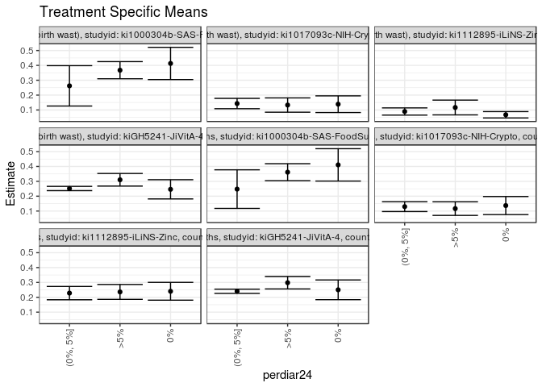

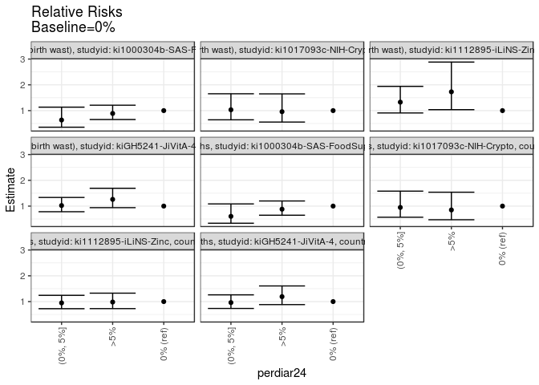

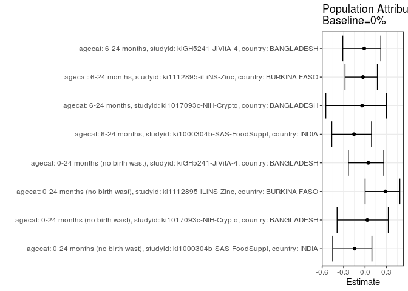

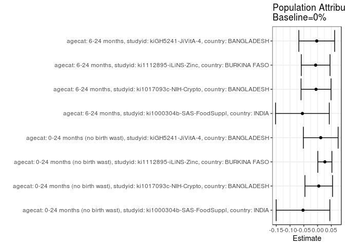

## Results Table

### Parameter: TSM

| agecat | studyid | country | intervention_level | baseline_level | estimate | ci_lower | ci_upper |
| --- | --- | --- | --- | --- | --- | --- | --- |
| 0-24 months (no birth wast) | ki1000304b-SAS-FoodSuppl | INDIA | 0% | NA | 0.4129891 | 0.3044242 | 0.5215540 |
| 0-24 months (no birth wast) | ki1000304b-SAS-FoodSuppl | INDIA | (0%, 5%] | NA | 0.2623631 | 0.1264963 | 0.3982300 |
| 0-24 months (no birth wast) | ki1000304b-SAS-FoodSuppl | INDIA | >5% | NA | 0.3675516 | 0.3098560 | 0.4252472 |
| 0-24 months (no birth wast) | ki1017093c-NIH-Crypto | BANGLADESH | 0% | NA | 0.1388695 | 0.0827551 | 0.1949839 |
| 0-24 months (no birth wast) | ki1017093c-NIH-Crypto | BANGLADESH | (0%, 5%] | NA | 0.1432868 | 0.1084993 | 0.1780742 |
| 0-24 months (no birth wast) | ki1017093c-NIH-Crypto | BANGLADESH | >5% | NA | 0.1330698 | 0.0849208 | 0.1812189 |
| 0-24 months (no birth wast) | ki1112895-iLiNS-Zinc | BURKINA FASO | 0% | NA | 0.0674946 | 0.0461719 | 0.0888172 |
| 0-24 months (no birth wast) | ki1112895-iLiNS-Zinc | BURKINA FASO | (0%, 5%] | NA | 0.0896299 | 0.0654783 | 0.1137815 |
| 0-24 months (no birth wast) | ki1112895-iLiNS-Zinc | BURKINA FASO | >5% | NA | 0.1166529 | 0.0669607 | 0.1663452 |
| 0-24 months (no birth wast) | kiGH5241-JiVitA-4 | BANGLADESH | 0% | NA | 0.2462030 | 0.1815926 | 0.3108134 |
| 0-24 months (no birth wast) | kiGH5241-JiVitA-4 | BANGLADESH | (0%, 5%] | NA | 0.2516301 | 0.2373109 | 0.2659492 |
| 0-24 months (no birth wast) | kiGH5241-JiVitA-4 | BANGLADESH | >5% | NA | 0.3104233 | 0.2680552 | 0.3527914 |
| 6-24 months | ki1000304b-SAS-FoodSuppl | INDIA | 0% | NA | 0.4107304 | 0.3018430 | 0.5196177 |
| 6-24 months | ki1000304b-SAS-FoodSuppl | INDIA | (0%, 5%] | NA | 0.2476225 | 0.1178767 | 0.3773684 |
| 6-24 months | ki1000304b-SAS-FoodSuppl | INDIA | >5% | NA | 0.3615536 | 0.3043885 | 0.4187186 |
| 6-24 months | ki1017093c-NIH-Crypto | BANGLADESH | 0% | NA | 0.1369866 | 0.0761833 | 0.1977900 |
| 6-24 months | ki1017093c-NIH-Crypto | BANGLADESH | (0%, 5%] | NA | 0.1297992 | 0.0965995 | 0.1629990 |
| 6-24 months | ki1017093c-NIH-Crypto | BANGLADESH | >5% | NA | 0.1165146 | 0.0706748 | 0.1623544 |
| 6-24 months | ki1112895-iLiNS-Zinc | BURKINA FASO | 0% | NA | 0.2404030 | 0.1805829 | 0.3002232 |
| 6-24 months | ki1112895-iLiNS-Zinc | BURKINA FASO | (0%, 5%] | NA | 0.2281219 | 0.1833455 | 0.2728982 |
| 6-24 months | ki1112895-iLiNS-Zinc | BURKINA FASO | >5% | NA | 0.2361401 | 0.1861446 | 0.2861356 |
| 6-24 months | kiGH5241-JiVitA-4 | BANGLADESH | 0% | NA | 0.2502464 | 0.1838462 | 0.3166465 |
| 6-24 months | kiGH5241-JiVitA-4 | BANGLADESH | (0%, 5%] | NA | 0.2406155 | 0.2264668 | 0.2547643 |
| 6-24 months | kiGH5241-JiVitA-4 | BANGLADESH | >5% | NA | 0.2980410 | 0.2561083 | 0.3399738 |

### Parameter: E(Y)

| agecat | studyid | country | intervention_level | baseline_level | estimate | ci_lower | ci_upper |
| --- | --- | --- | --- | --- | --- | --- | --- |
| 0-24 months (no birth wast) | ki1000304b-SAS-FoodSuppl | INDIA | NA | NA | 0.3602015 | 0.3129196 | 0.4074834 |
| 0-24 months (no birth wast) | ki1017093c-NIH-Crypto | BANGLADESH | NA | NA | 0.1432361 | 0.1182149 | 0.1682572 |
| 0-24 months (no birth wast) | ki1112895-iLiNS-Zinc | BURKINA FASO | NA | NA | 0.0941227 | 0.0721577 | 0.1160876 |
| 0-24 months (no birth wast) | kiGH5241-JiVitA-4 | BANGLADESH | NA | NA | 0.2577835 | 0.2441424 | 0.2714247 |
| 6-24 months | ki1000304b-SAS-FoodSuppl | INDIA | NA | NA | 0.3557214 | 0.3088651 | 0.4025777 |
| 6-24 months | ki1017093c-NIH-Crypto | BANGLADESH | NA | NA | 0.1315068 | 0.1069744 | 0.1560393 |
| 6-24 months | ki1112895-iLiNS-Zinc | BURKINA FASO | NA | NA | 0.2334694 | 0.1980609 | 0.2688779 |
| 6-24 months | kiGH5241-JiVitA-4 | BANGLADESH | NA | NA | 0.2473297 | 0.2337864 | 0.2608729 |

### Parameter: RR

| agecat | studyid | country | intervention_level | baseline_level | estimate | ci_lower | ci_upper |
| --- | --- | --- | --- | --- | --- | --- | --- |
| 0-24 months (no birth wast) | ki1000304b-SAS-FoodSuppl | INDIA | 0% | 0% | 1.0000000 | 1.0000000 | 1.000000 |
| 0-24 months (no birth wast) | ki1000304b-SAS-FoodSuppl | INDIA | (0%, 5%] | 0% | 0.6352786 | 0.3559503 | 1.133807 |
| 0-24 months (no birth wast) | ki1000304b-SAS-FoodSuppl | INDIA | >5% | 0% | 0.8899790 | 0.6547859 | 1.209652 |
| 0-24 months (no birth wast) | ki1017093c-NIH-Crypto | BANGLADESH | 0% | 0% | 1.0000000 | 1.0000000 | 1.000000 |
| 0-24 months (no birth wast) | ki1017093c-NIH-Crypto | BANGLADESH | (0%, 5%] | 0% | 1.0318089 | 0.6438097 | 1.653640 |
| 0-24 months (no birth wast) | ki1017093c-NIH-Crypto | BANGLADESH | >5% | 0% | 0.9582367 | 0.5569027 | 1.648794 |
| 0-24 months (no birth wast) | ki1112895-iLiNS-Zinc | BURKINA FASO | 0% | 0% | 1.0000000 | 1.0000000 | 1.000000 |
| 0-24 months (no birth wast) | ki1112895-iLiNS-Zinc | BURKINA FASO | (0%, 5%] | 0% | 1.3279579 | 0.9087873 | 1.940468 |
| 0-24 months (no birth wast) | ki1112895-iLiNS-Zinc | BURKINA FASO | >5% | 0% | 1.7283312 | 1.0364329 | 2.882125 |
| 0-24 months (no birth wast) | kiGH5241-JiVitA-4 | BANGLADESH | 0% | 0% | 1.0000000 | 1.0000000 | 1.000000 |
| 0-24 months (no birth wast) | kiGH5241-JiVitA-4 | BANGLADESH | (0%, 5%] | 0% | 1.0220430 | 0.7819865 | 1.335793 |
| 0-24 months (no birth wast) | kiGH5241-JiVitA-4 | BANGLADESH | >5% | 0% | 1.2608428 | 0.9400236 | 1.691154 |
| 6-24 months | ki1000304b-SAS-FoodSuppl | INDIA | 0% | 0% | 1.0000000 | 1.0000000 | 1.000000 |
| 6-24 months | ki1000304b-SAS-FoodSuppl | INDIA | (0%, 5%] | 0% | 0.6028834 | 0.3351724 | 1.084422 |
| 6-24 months | ki1000304b-SAS-FoodSuppl | INDIA | >5% | 0% | 0.8802698 | 0.6461885 | 1.199147 |
| 6-24 months | ki1017093c-NIH-Crypto | BANGLADESH | 0% | 0% | 1.0000000 | 1.0000000 | 1.000000 |
| 6-24 months | ki1017093c-NIH-Crypto | BANGLADESH | (0%, 5%] | 0% | 0.9475322 | 0.5682930 | 1.579849 |
| 6-24 months | ki1017093c-NIH-Crypto | BANGLADESH | >5% | 0% | 0.8505546 | 0.4701773 | 1.538660 |
| 6-24 months | ki1112895-iLiNS-Zinc | BURKINA FASO | 0% | 0% | 1.0000000 | 1.0000000 | 1.000000 |
| 6-24 months | ki1112895-iLiNS-Zinc | BURKINA FASO | (0%, 5%] | 0% | 0.9489144 | 0.7244886 | 1.242861 |
| 6-24 months | ki1112895-iLiNS-Zinc | BURKINA FASO | >5% | 0% | 0.9822677 | 0.7270488 | 1.327077 |
| 6-24 months | kiGH5241-JiVitA-4 | BANGLADESH | 0% | 0% | 1.0000000 | 1.0000000 | 1.000000 |
| 6-24 months | kiGH5241-JiVitA-4 | BANGLADESH | (0%, 5%] | 0% | 0.9615146 | 0.7330847 | 1.261124 |
| 6-24 months | kiGH5241-JiVitA-4 | BANGLADESH | >5% | 0% | 1.1909905 | 0.8830029 | 1.606403 |

### Parameter: PAR

| agecat | studyid | country | intervention_level | baseline_level | estimate | ci_lower | ci_upper |
| --- | --- | --- | --- | --- | --- | --- | --- |
| 0-24 months (no birth wast) | ki1000304b-SAS-FoodSuppl | INDIA | 0% | NA | -0.0527876 | -0.1502864 | 0.0447112 |
| 0-24 months (no birth wast) | ki1017093c-NIH-Crypto | BANGLADESH | 0% | NA | 0.0043666 | -0.0457583 | 0.0544914 |
| 0-24 months (no birth wast) | ki1112895-iLiNS-Zinc | BURKINA FASO | 0% | NA | 0.0266281 | 0.0010024 | 0.0522539 |
| 0-24 months (no birth wast) | kiGH5241-JiVitA-4 | BANGLADESH | 0% | NA | 0.0115805 | -0.0515383 | 0.0746993 |
| 6-24 months | ki1000304b-SAS-FoodSuppl | INDIA | 0% | NA | -0.0550090 | -0.1526861 | 0.0426681 |
| 6-24 months | ki1017093c-NIH-Crypto | BANGLADESH | 0% | NA | -0.0054798 | -0.0598780 | 0.0489185 |
| 6-24 months | ki1112895-iLiNS-Zinc | BURKINA FASO | 0% | NA | -0.0069336 | -0.0590916 | 0.0452244 |
| 6-24 months | kiGH5241-JiVitA-4 | BANGLADESH | 0% | NA | -0.0029167 | -0.0679052 | 0.0620718 |

### Parameter: PAF

| agecat | studyid | country | intervention_level | baseline_level | estimate | ci_lower | ci_upper |
| --- | --- | --- | --- | --- | --- | --- | --- |
| 0-24 months (no birth wast) | ki1000304b-SAS-FoodSuppl | INDIA | 0% | NA | -0.1465501 | -0.4525964 | 0.0950156 |
| 0-24 months (no birth wast) | ki1017093c-NIH-Crypto | BANGLADESH | 0% | NA | 0.0304852 | -0.3910433 | 0.3242777 |
| 0-24 months (no birth wast) | ki1112895-iLiNS-Zinc | BURKINA FASO | 0% | NA | 0.2829086 | 0.0007102 | 0.4854144 |
| 0-24 months (no birth wast) | kiGH5241-JiVitA-4 | BANGLADESH | 0% | NA | 0.0449234 | -0.2342009 | 0.2609216 |
| 6-24 months | ki1000304b-SAS-FoodSuppl | INDIA | 0% | NA | -0.1546406 | -0.4652484 | 0.0901236 |
| 6-24 months | ki1017093c-NIH-Crypto | BANGLADESH | 0% | NA | -0.0416691 | -0.5490165 | 0.2995074 |
| 6-24 months | ki1112895-iLiNS-Zinc | BURKINA FASO | 0% | NA | -0.0296982 | -0.2798445 | 0.1715569 |
| 6-24 months | kiGH5241-JiVitA-4 | BANGLADESH | 0% | NA | -0.0117928 | -0.3118286 | 0.2196201 |